# How Far will It Go in (MPG) Lets Play Prediction Game

author: Manil Wagle date: 21 October 2015 transition: rotate

# Introduction

Developing Data Products is the final series of lecture in Data Science Specilization. This course requires us to do a project which involves building an application using shiny platform.This presentation aims to describe about ThePredictionGame application. The criteria given while creating this presentation areT.

1. 5 slides to pictch our idea in Slidify or Rstudio Presenter
2. It must be hosted on github or Rpubs.
3. It must contain some embedded R code that gets run when slidifying the document.

The Shiny app is hosted on https://manil.shinyapps.io/ThePredictionGame.

The R Presentation is available at http://rpubs.com/manilwagle/117392 and http://rpubs.com/manilwagle/116673

Source code for ui.R and server.R files are available in my [GitHub repository]https://github.com/manilwagle/Developing_Data_Products.

# mtcars Dataset

The application is designed to predict what mileage can be expected from the car based on the specified attributes as those informations will be required to run the application: The application uses mtcar Datasets.

What is the weight of the car(in 1000 lbs) What is the horsepower of the car How many cylinders are in the car (4, 6, or 8 ) What type of transmission does the car have, is it Automatic or Manual)

```r
head(mtcars)
```

```
                   mpg cyl disp  hp drat    wt  qsec vs am gear carb
Mazda RX4         21.0   6  160 110 3.90 2.620 16.46  0  1    4    4
Mazda RX4 Wag     21.0   6  160 110 3.90 2.875 17.02  0  1    4    4
Datsun 710        22.8   4  108  93 3.85 2.320 18.61  1  1    4    1
Hornet 4 Drive    21.4   6  258 110 3.08 3.215 19.44  1  0    3    1
Hornet Sportabout 18.7   8  360 175 3.15 3.440 17.02  0  0    3    2
Valiant           18.1   6  225 105 2.76 3.460 20.22  1  0    3    1
```

# Things to Remember while using the application

Some of the things to consider while using the application:

1. Be familiar with the information about the car.
2. Once information inputted, please press Ready to Go Button.
3. The expected value will be displayed in The Magic Box.

Click the Ready To Go button

The Magic Box will displayed the expected value.

# The PredictionGame Application Screen

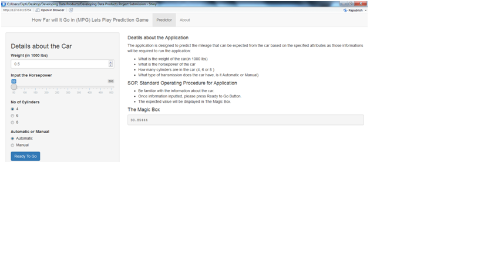